# Analysis Script - Bias in AI

Vorisek_CN

30 12 2021

## Prepare Analysis

*Load relevant libraries*

```r
library(readxl)
library(tidyverse)
library(writexl)
library(knitr)
library(arsenal)
library(data.table)
```

```r
library(ggplot2)
library(dplyr)
library(ggplot2)
library(ggpubr)
```

*Bar theme*

colors: https://www.datanovia.com/en/blog/ggplot-colors-best-tricks-you-will-love/

```r
# define theme and colors for barplots
bar_theme <-   theme(rect = element_blank(),
        axis.ticks.y = element_line(color = "grey40"),
        panel.grid.major.x = element_line(color = "grey90"))
bar_color <-  "#C4961A"
bar_width <- 0.6
```

*Read in file created in “Data_Preparation.Rmd” and “Data Cleaning.Rmd”*

```r
analysis <- read_excel("AnalysisFile_Bias_AI.xlsx")
View(analysis)
```

# Demographics

**Prepare Data**

```r
analysis$arbeitsland = as.factor(analysis$arbeitsland)
analysis$geschlecht = as.factor(analysis$geschlecht)
analysis$sektor = as.factor(analysis$sektor)
analysis$quelle = as.factor(analysis$quelle)
analysis$alter = as.numeric(analysis$alter)
```

# Age group

```r
setDT(analysis)
```

### create category age group

```r
analysis[,agegroup4:= cut(alter,4,include.lowest=TRUE,
           labels=c("<30","30-40","40-50",">50"))]
analysis[,table(agegroup4)]
```

```
## agegroup4
##   <30 30-40 40-50   >50
##    69    49    24     9
```

## How did this questionnaire reach you?

```r
source <- analysis %>%
  group_by(quelle) %>%
  summarize(N = n()) %>%
  mutate(Percent = N / sum(N) * 100,
         Percent = round(Percent, 1)) %>%
  arrange(desc(N))

source$quelle <- factor(source$quelle,levels = c(1,2,3,4,5,6), labels = c("Twitter","Linkedin","Email distribution\nlist of my institution", "Personal contact", "Other", "Not specified"))

knitr::kable(source)
```

| quelle | N | Percent |
| --- | --- | --- |
| Email distribution |  |  |
| list of my institution | 72 | 47.7 |
| Linkedin | 25 | 16.6 |
| Personal contact | 25 | 16.6 |
| Other | 16 | 10.6 |
| Twitter | 11 | 7.3 |
| Not specified | 2 | 1.3 |

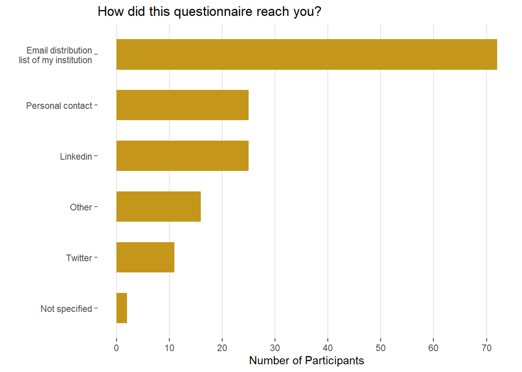

```r
source_plot <- ggplot(source) + geom_col(aes(reorder(quelle, N, sum), N),
                              fill = bar_color,
                              width = bar_width) +
  labs(x = "", y = "Number of Participants", title = "How did this questionnaire reach you?") +
  scale_y_continuous(breaks = seq(0,100,10)) +
  coord_flip() +
  bar_theme

source_plot
```

## Which country do you work in?

```r
country <- analysis %>%
  group_by(arbeitsland) %>%
  summarize(N = n()) %>%
  mutate(Percent = N / sum(N) * 100,
         Percent = round(Percent, 1)) %>%
  arrange(desc(N))

knitr::kable(country)
```

| arbeitsland | N | Percent |
| --- | --- | --- |
| 2 | 139 | 92.1 |
| 28 | 5 | 3.3 |
| 11 | 1 | 0.7 |
| 12 | 1 | 0.7 |
| 13 | 1 | 0.7 |
| 22 | 1 | 0.7 |
| 23 | 1 | 0.7 |
| 3 | 1 | 0.7 |
| 6 | 1 | 0.7 |

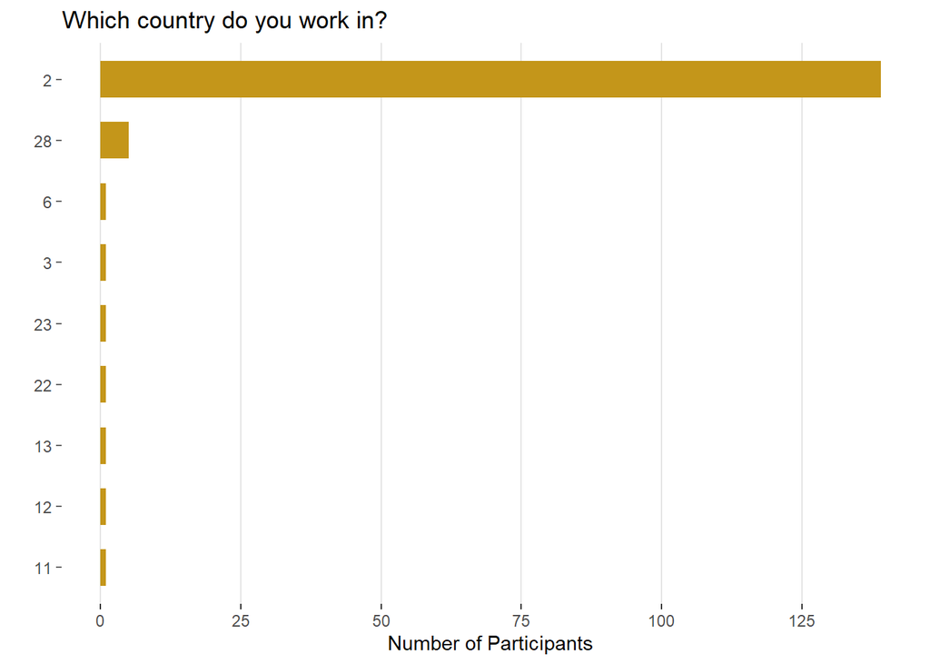

```r
country_plot <- ggplot(country) + geom_col(aes(reorder(arbeitsland, N, sum), N),
                              fill = bar_color,
                              width = bar_width) +
  labs(x = "", y = "Number of Participants", title = "Which country do you work in?") +
  scale_y_continuous(breaks = seq(0,150,25)) +
  coord_flip() +
  bar_theme

country_plot
```

## What is your gender?

```r
gender <- analysis %>%
  group_by(geschlecht) %>%
  summarize(N = n()) %>%
  mutate(Percent = N / sum(N) * 100,
         Percent = round(Percent, 1)) %>%
  arrange(desc(N))

gender$geschlecht <- factor(gender$geschlecht,levels = c(1,2,3,4,5), labels = c("Female","Male","Diverse", "Undefined", "Not specified"))

knitr::kable(gender)
```

| geschlecht | N | Percent |
| --- | --- | --- |
| Male | 101 | 66.9 |
| Female | 45 | 29.8 |
| Undefined | 2 | 1.3 |
| Not specified | 2 | 1.3 |
| Diverse | 1 | 0.7 |

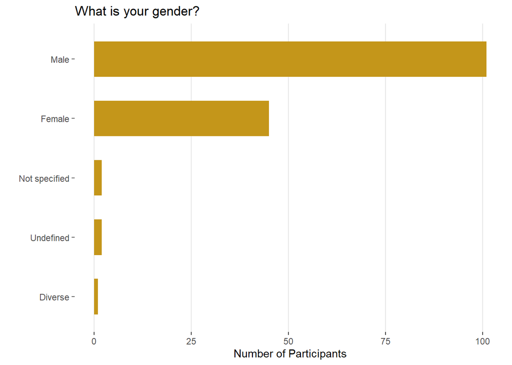

```r
gender_plot <- ggplot(gender) + geom_col(aes(reorder(geschlecht, N, sum), N),
                              fill = bar_color,
                              width = bar_width) +
  labs(x = "", y = "Number of Participants", title = "What is your gender?") +
  scale_y_continuous(breaks = seq(0,200,25)) +
  coord_flip() +
  bar_theme

gender_plot
```

## What is your age?

*check for normality*

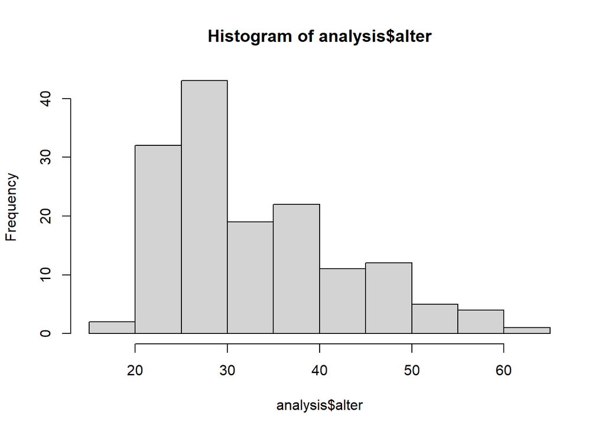

```r
hist(analysis$alter)
```

```r
summary.default(analysis$alter)
```

```
##    Min. 1st Qu.  Median    Mean 3rd Qu.    Max.
##   19.00   26.00   30.00   33.62   39.00   62.00
```

## Age Group

```r
ageGroup <- analysis %>%
  group_by(agegroup4) %>%
  summarize(N = n()) %>%
  mutate(Percent = N / sum(N) * 100,
         Percent = round(Percent, 1)) %>%
  arrange(desc(N))


knitr::kable(ageGroup)
```

| agegroup4 | N | Percent |
| --- | --- | --- |
| <30 | 69 | 45.7 |
| 30-40 | 49 | 32.5 |
| 40-50 | 24 | 15.9 |
| >50 | 9 | 6.0 |

group by median

```r
analysis$agegroup2 <- as.factor(ifelse(analysis$alter <30, 1, 0))
```

```r
ageGroup_2 <- analysis %>%
  group_by(agegroup2) %>%
  summarize(N = n()) %>%
  mutate(Percent = N / sum(N) * 100,
         Percent = round(Percent, 1)) %>%
  arrange(desc(N))


knitr::kable(ageGroup_2)
```

| agegroup2 | N | Percent |
| --- | --- | --- |
| 0 | 82 | 54.3 |
| 1 | 69 | 45.7 |

## In which area do you work in?

```r
section <- analysis %>%
  group_by(sektor) %>%
  summarize(N = n()) %>%
  mutate(Percent = N / sum(N) * 100,
         Percent = round(Percent, 1)) %>%
  arrange(desc(N))

section$sektor <- factor(section$sektor,levels = c(1,2,3,4,5), labels = c("Science","Clinical Work","Industry", "Other", "Not specified"))

knitr::kable(section)
```

| sektor | N | Percent |
| --- | --- | --- |
| Science | 104 | 68.9 |
| Industry | 22 | 14.6 |
| Clinical Work | 12 | 7.9 |
| Other | 11 | 7.3 |
| Not specified | 2 | 1.3 |

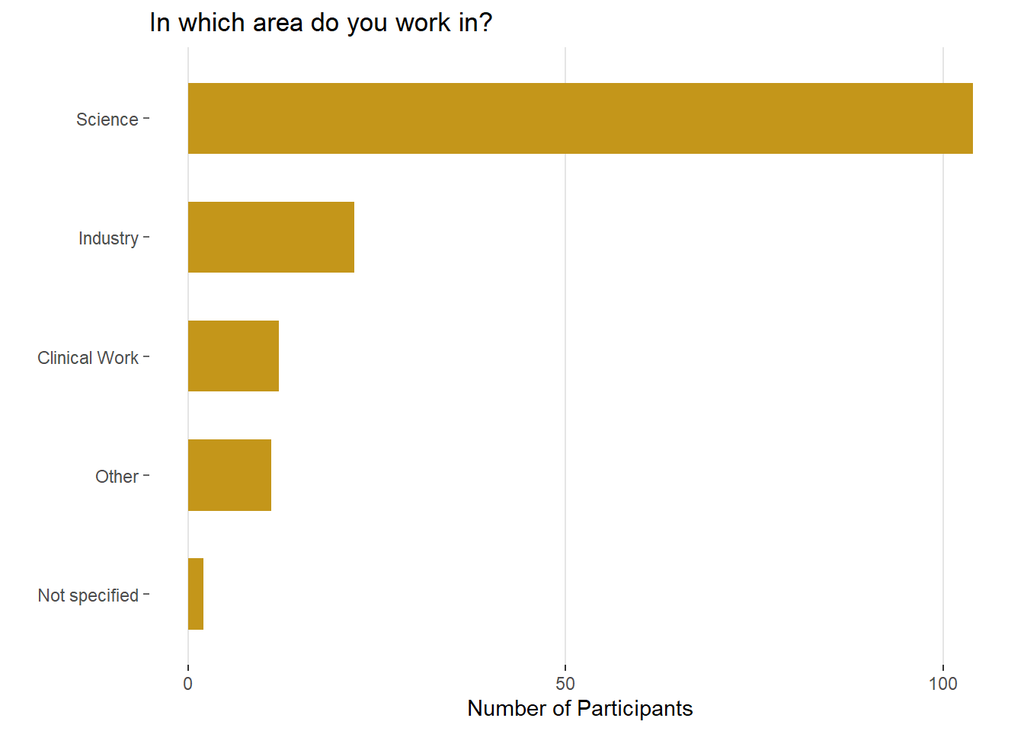

```r
ggplot(section) + geom_col(aes(reorder(sektor, N, sum), N),
                              fill = bar_color,
                              width = bar_width) +
  labs(x = "", y = "Number of Participants", title = "In which area do you work in?") +
  scale_y_continuous(breaks = seq(0,200,50)) +
  coord_flip() +
  bar_theme
```

## At what stage are you or have you been developing AI-projects?

```r
which(colnames(analysis) == "ki_entwicklungsphase___1")
```

```
## [1] 19
```

```r
which(colnames(analysis) == "ki_entwicklungsphase___8")
```

```
## [1] 26
```

*create dataset*

```r
kiphase<-analysis %>% select(19:26)

view(kiphase)
```

**Multi-response analysis** *Pct.of.cases is the percentage of respondents who selected that particular option. You’ll notice that these don’t add up to 100% because people could choose more than one option.Pct.of.resp. is the percentage of responses (so not like I said in the video respondents, but responses). These do add up to 100%.*

```r
kiphase_analysis <-data.frame(Freq = colSums(kiphase),
           Pct.of.Resp = (colSums(kiphase)/sum(kiphase))*100,
           Pct.of.Cases = (colSums(kiphase)/nrow(kiphase))*100)

rownames(kiphase_analysis) <- c("Project planning","Data acquisition/\ndata preprocessing","Data annotation","Identification\nof AI algorithms", "Training and\noptimization", "Practical testing\nof AI algorithms", "Other", "Not specified")

knitr::kable(kiphase_analysis)
```

|  | Freq | Pct.of.Resp | Pct.of.Cases |
| --- | --- | --- | --- |
| Project planning | 82 | 16.173570 | 54.304636 |
| Data acquisition/ |  |  |  |
| data preprocessing | 84 | 16.568047 | 55.629139 |
| Data annotation | 61 | 12.031558 | 40.397351 |
| Identification |  |  |  |
| of AI algorithms | 83 | 16.370809 | 54.966887 |
| Training and |  |  |  |
| optimization | 105 | 20.710059 | 69.536424 |
| Practical testing |  |  |  |
| of AI algorithms | 79 | 15.581854 | 52.317881 |
| Other | 6 | 1.183432 | 3.973510 |
| Not specified | 7 | 1.380671 | 4.635762 |

*create bar graph* *rownames as column*

```r
kiphase_analysis1 <- kiphase_analysis
kiphase_analysis1$row_names <- row.names(kiphase_analysis1)
kiphase_analysis1
```

```
##                                       Freq Pct.of.Resp Pct.of.Cases
## Project planning                        82   16.173570    54.304636
## Data acquisition/\ndata preprocessing   84   16.568047    55.629139
## Data annotation                         61   12.031558    40.397351
## Identification\nof AI algorithms        83   16.370809    54.966887
## Training and\noptimization             105   20.710059    69.536424
## Practical testing\nof AI algorithms     79   15.581854    52.317881
## Other                                    6    1.183432     3.973510
## Not specified                            7    1.380671     4.635762
##                                                                   row_names
## Project planning                                           Project planning
## Data acquisition/\ndata preprocessing Data acquisition/\ndata preprocessing
## Data annotation                                             Data annotation
## Identification\nof AI algorithms           Identification\nof AI algorithms
## Training and\noptimization                       Training and\noptimization
## Practical testing\nof AI algorithms     Practical testing\nof AI algorithms
## Other                                                                 Other
## Not specified                                                 Not specified
```

*graph*

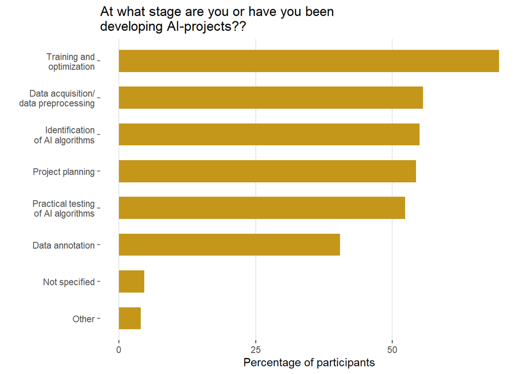

```r
ggplot(kiphase_analysis1) + geom_col(aes(reorder(row_names, Pct.of.Cases, sum), Pct.of.Cases),
                              fill = bar_color,
                              width = bar_width) +
  labs(x = "", y = "Percentage of participants", title = "At what stage are you or have you been\ndeveloping AI-projects??") +
  scale_y_continuous(breaks = seq(0,200,25)) +
  coord_flip() +
  bar_theme
```

## In which medical specialty are you developing AI solutions?

```r
which(colnames(analysis) == "med_fachbereich___1")
```

```
## [1] 28
```

```r
which(colnames(analysis) == "med_fachbereich___37")
```

```
## [1] 64
```

*create dataset*

```r
specialty<-analysis %>% select(28:64)
view(specialty)
```

**Multi-response analysis** *Pct.of.cases is the percentage of respondents who selected that particular option. You’ll notice that these don’t add up to 100% because people could choose more than one option.Pct.of.resp. is the percentage of responses (so not like I said in the video respondents, but responses). These do add up to 100%.*

```r
specialty_analysis <-data.frame(Freq = colSums(specialty),
           Pct.of.Resp = (colSums(specialty)/sum(specialty))*100,
           Pct.of.Cases = (colSums(specialty)/nrow(specialty))*100)



knitr::kable(specialty_analysis)
```

|  | Freq | Pct.of.Resp | Pct.of.Cases |
| --- | --- | --- | --- |
| med_fachbereich___1 | 14 | 5.1470588 | 9.2715232 |
| med_fachbereich___2 | 6 | 2.2058824 | 3.9735099 |
| med_fachbereich___3 | 1 | 0.3676471 | 0.6622517 |
| med_fachbereich___4 | 1 | 0.3676471 | 0.6622517 |
| med_fachbereich___5 | 6 | 2.2058824 | 3.9735099 |
| med_fachbereich___6 | 6 | 2.2058824 | 3.9735099 |
| med_fachbereich___7 | 14 | 5.1470588 | 9.2715232 |
| med_fachbereich___8 | 2 | 0.7352941 | 1.3245033 |
| med_fachbereich___9 | 2 | 0.7352941 | 1.3245033 |
| med_fachbereich___10 | 6 | 2.2058824 | 3.9735099 |
| med_fachbereich___11 | 3 | 1.1029412 | 1.9867550 |
| med_fachbereich___12 | 4 | 1.4705882 | 2.6490066 |
| med_fachbereich___13 | 21 | 7.7205882 | 13.9072848 |
| med_fachbereich___14 | 2 | 0.7352941 | 1.3245033 |
| med_fachbereich___15 | 2 | 0.7352941 | 1.3245033 |
| med_fachbereich___16 | 6 | 2.2058824 | 3.9735099 |
| med_fachbereich___17 | 5 | 1.8382353 | 3.3112583 |
| med_fachbereich___18 | 1 | 0.3676471 | 0.6622517 |
| med_fachbereich___19 | 2 | 0.7352941 | 1.3245033 |
| med_fachbereich___20 | 10 | 3.6764706 | 6.6225166 |
| med_fachbereich___21 | 5 | 1.8382353 | 3.3112583 |
| med_fachbereich___22 | 11 | 4.0441176 | 7.2847682 |
| med_fachbereich___23 | 7 | 2.5735294 | 4.6357616 |
| med_fachbereich___24 | 3 | 1.1029412 | 1.9867550 |
| med_fachbereich___25 | 0 | 0.0000000 | 0.0000000 |
| med_fachbereich___26 | 0 | 0.0000000 | 0.0000000 |
| med_fachbereich___27 | 2 | 0.7352941 | 1.3245033 |
| med_fachbereich___28 | 1 | 0.3676471 | 0.6622517 |
| med_fachbereich___29 | 1 | 0.3676471 | 0.6622517 |
| med_fachbereich___30 | 32 | 11.7647059 | 21.1920530 |
| med_fachbereich___31 | 0 | 0.0000000 | 0.0000000 |
| med_fachbereich___32 | 3 | 1.1029412 | 1.9867550 |
| med_fachbereich___33 | 2 | 0.7352941 | 1.3245033 |
| med_fachbereich___34 | 2 | 0.7352941 | 1.3245033 |
| med_fachbereich___35 | 38 | 13.9705882 | 25.1655629 |
| med_fachbereich___36 | 22 | 8.0882353 | 14.5695364 |
| med_fachbereich___37 | 29 | 10.6617647 | 19.2052980 |

*create bar graph* *rownames as column*

```r
specialty_analysis1 <- specialty_analysis
specialty_analysis1$row_names <- row.names(specialty_analysis1)
specialty_analysis1
```

```
##                      Freq Pct.of.Resp Pct.of.Cases            row_names
## med_fachbereich___1    14   5.1470588    9.2715232  med_fachbereich___1
## med_fachbereich___2     6   2.2058824    3.9735099  med_fachbereich___2
## med_fachbereich___3     1   0.3676471    0.6622517  med_fachbereich___3
## med_fachbereich___4     1   0.3676471    0.6622517  med_fachbereich___4
## med_fachbereich___5     6   2.2058824    3.9735099  med_fachbereich___5
## med_fachbereich___6     6   2.2058824    3.9735099  med_fachbereich___6
## med_fachbereich___7    14   5.1470588    9.2715232  med_fachbereich___7
## med_fachbereich___8     2   0.7352941    1.3245033  med_fachbereich___8
## med_fachbereich___9     2   0.7352941    1.3245033  med_fachbereich___9
## med_fachbereich___10    6   2.2058824    3.9735099 med_fachbereich___10
## med_fachbereich___11    3   1.1029412    1.9867550 med_fachbereich___11
## med_fachbereich___12    4   1.4705882    2.6490066 med_fachbereich___12
## med_fachbereich___13   21   7.7205882   13.9072848 med_fachbereich___13
## med_fachbereich___14    2   0.7352941    1.3245033 med_fachbereich___14
## med_fachbereich___15    2   0.7352941    1.3245033 med_fachbereich___15
## med_fachbereich___16    6   2.2058824    3.9735099 med_fachbereich___16
## med_fachbereich___17    5   1.8382353    3.3112583 med_fachbereich___17
## med_fachbereich___18    1   0.3676471    0.6622517 med_fachbereich___18
## med_fachbereich___19    2   0.7352941    1.3245033 med_fachbereich___19
## med_fachbereich___20   10   3.6764706    6.6225166 med_fachbereich___20
## med_fachbereich___21    5   1.8382353    3.3112583 med_fachbereich___21
## med_fachbereich___22   11   4.0441176    7.2847682 med_fachbereich___22
## med_fachbereich___23    7   2.5735294    4.6357616 med_fachbereich___23
## med_fachbereich___24    3   1.1029412    1.9867550 med_fachbereich___24
## med_fachbereich___25    0   0.0000000    0.0000000 med_fachbereich___25
## med_fachbereich___26    0   0.0000000    0.0000000 med_fachbereich___26
## med_fachbereich___27    2   0.7352941    1.3245033 med_fachbereich___27
## med_fachbereich___28    1   0.3676471    0.6622517 med_fachbereich___28
## med_fachbereich___29    1   0.3676471    0.6622517 med_fachbereich___29
## med_fachbereich___30   32  11.7647059   21.1920530 med_fachbereich___30
## med_fachbereich___31    0   0.0000000    0.0000000 med_fachbereich___31
## med_fachbereich___32    3   1.1029412    1.9867550 med_fachbereich___32
## med_fachbereich___33    2   0.7352941    1.3245033 med_fachbereich___33
## med_fachbereich___34    2   0.7352941    1.3245033 med_fachbereich___34
## med_fachbereich___35   38  13.9705882   25.1655629 med_fachbereich___35
## med_fachbereich___36   22   8.0882353   14.5695364 med_fachbereich___36
## med_fachbereich___37   29  10.6617647   19.2052980 med_fachbereich___37
```

*graph*

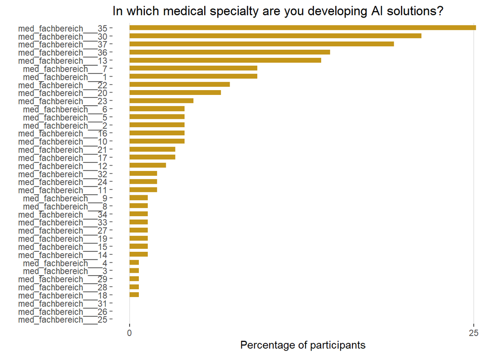

```r
ggplot(specialty_analysis1) + geom_col(aes(reorder(row_names, Pct.of.Cases, sum), Pct.of.Cases),
                              fill = bar_color,
                              width = bar_width) +
  labs(x = "", y = "Percentage of participants", title = "In which medical specialty are you developing AI solutions?") +
  scale_y_continuous(breaks = seq(0,200,25)) +
  coord_flip() +
  bar_theme
```

## In which of the following areas of AI are you developing?

```r
which(colnames(analysis) == "ki_art___1")
```

```
## [1] 66
```

```r
which(colnames(analysis) == "ki_art___4")
```

```
## [1] 69
```

*create dataset*

```r
areas<-analysis %>% select( 66:69)
view(areas)
```

**Multi-response analysis** *Pct.of.cases is the percentage of respondents who selected that particular option. You’ll notice that these don’t add up to 100% because people could choose more than one option.Pct.of.resp. is the percentage of responses (so not like I said in the video respondents, but responses). These do add up to 100%.*

```r
areas_analysis <-data.frame(Freq = colSums(areas),
           Pct.of.Resp = (colSums(areas)/sum(areas))*100,
           Pct.of.Cases = (colSums(areas)/nrow(areas))*100)
```

```r
rownames(areas_analysis) <- c("Machine Learning","Deep Learning","Other type of AI", "Not specified")
knitr::kable(areas_analysis)
```

|  | Freq | Pct.of.Resp | Pct.of.Cases |
| --- | --- | --- | --- |
| Machine Learning | 105 | 43.56846 | 69.536424 |
| Deep Learning | 86 | 35.68465 | 56.953642 |
| Other type of AI | 41 | 17.01245 | 27.152318 |
| Not specified | 9 | 3.73444 | 5.960265 |

*create bar graph* *rownames as column*

```r
areas_analysis1 <- areas_analysis
areas_analysis1$row_names <- row.names(areas_analysis1)
areas_analysis1
```

```
##                  Freq Pct.of.Resp Pct.of.Cases        row_names
## Machine Learning  105    43.56846    69.536424 Machine Learning
## Deep Learning      86    35.68465    56.953642    Deep Learning
## Other type of AI   41    17.01245    27.152318 Other type of AI
## Not specified       9     3.73444     5.960265    Not specified
```

*graph*

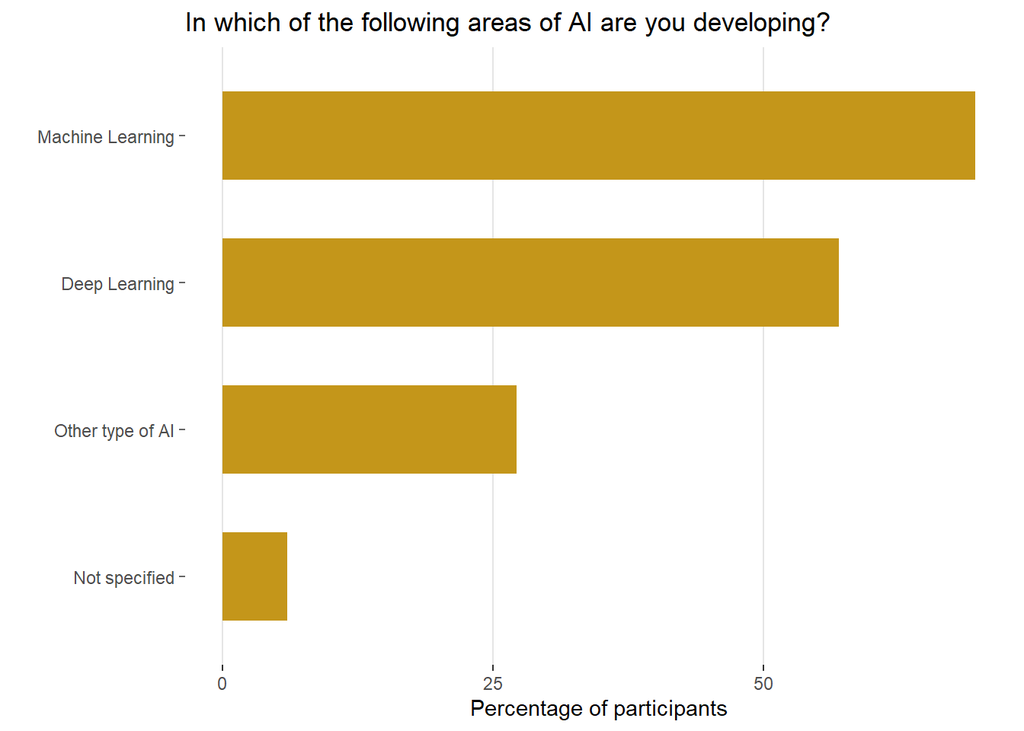

```r
ggplot(areas_analysis1) + geom_col(aes(reorder(row_names, Pct.of.Cases, sum), Pct.of.Cases),
                              fill = bar_color,
                              width = bar_width) +
  labs(x = "", y = "Percentage of participants", title = "In which of the following areas of AI are you developing?") +
  scale_y_continuous(breaks = seq(0,200,25)) +
  coord_flip() +
  bar_theme
```

## Please specify the type of Machine Learning (ML) you aredeveloping:

```r
which(colnames(analysis) == "ki_art_ml___1")
```

```
## [1] 70
```

```r
which(colnames(analysis) == "ki_art_ml___6")
```

```
## [1] 75
```

```r
ml <-analysis %>% select( 70:75)
view(ml)
```

**Multi-response analysis** *Pct.of.cases is the percentage of respondents who selected that particular option. You’ll notice that these don’t add up to 100% because people could choose more than one option.Pct.of.resp. is the percentage of responses (so not like I said in the video respondents, but responses). These do add up to 100%.*

```r
ml_analysis <-data.frame(Freq = colSums(ml),
           Pct.of.Resp = (colSums(ml)/sum(ml))*100,
           Pct.of.Cases = (colSums(ml)/nrow(ml))*100)

rownames(ml_analysis) <- c("Supervised ML","Semi-supervised ML","Unsupervised ML", "Reinforcement learning", "Other", "Not specified")

knitr::kable(ml_analysis)
```

|  | Freq | Pct.of.Resp | Pct.of.Cases |
| --- | --- | --- | --- |
| Supervised ML | 80 | 40.609137 | 52.980133 |
| Semi-supervised ML | 42 | 21.319797 | 27.814570 |
| Unsupervised ML | 41 | 20.812183 | 27.152318 |
| Reinforcement learning | 21 | 10.659899 | 13.907285 |
| Other | 7 | 3.553300 | 4.635762 |
| Not specified | 6 | 3.045685 | 3.973510 |

*create bar graph* *rownames as column*

```r
ml_analysis1 <- ml_analysis
ml_analysis1$row_names <- row.names(ml_analysis1)
ml_analysis1
```

```
##                        Freq Pct.of.Resp Pct.of.Cases              row_names
## Supervised ML            80   40.609137    52.980132          Supervised ML
## Semi-supervised ML       42   21.319797    27.814570     Semi-supervised ML
## Unsupervised ML          41   20.812183    27.152318        Unsupervised ML
## Reinforcement learning   21   10.659898    13.907285 Reinforcement learning
## Other                     7    3.553299     4.635762                  Other
## Not specified             6    3.045685     3.973510          Not specified
```

*graph*

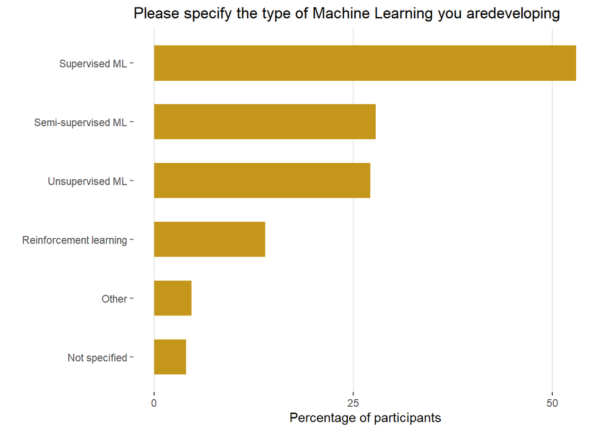

```r
ggplot(ml_analysis1) + geom_col(aes(reorder(row_names, Pct.of.Cases, sum), Pct.of.Cases),
                              fill = bar_color,
                              width = bar_width) +
  labs(x = "", y = "Percentage of participants", title = "Please specify the type of Machine Learning you aredeveloping") +
  scale_y_continuous(breaks = seq(0,200,25)) +
  coord_flip() +
  bar_theme
```

## Please specify the type of Deep Learning you are developing:

```r
which(colnames(analysis) == "ki_art_dl___1")
```

```
## [1] 76
```

```r
which(colnames(analysis) == "ki_art_dl___5")
```

```
## [1] 80
```

```r
dl <-analysis %>% select( 76:80)
view(dl)
```

**Multi-response analysis** *Pct.of.cases is the percentage of respondents who selected that particular option. You’ll notice that these don’t add up to 100% because people could choose more than one option.Pct.of.resp. is the percentage of responses (so not like I said in the video respondents, but responses). These do add up to 100%.*

```r
dl_analysis <-data.frame(Freq = colSums(dl),
           Pct.of.Resp = (colSums(dl)/sum(dl))*100,
           Pct.of.Cases = (colSums(dl)/nrow(dl))*100)

rownames(dl_analysis) <- c("Convolutional Networks","Recurrent neural Networks","Autoencoders", "Other", "Not specified")

knitr::kable(dl_analysis)
```

|  | Freq | Pct.of.Resp | Pct.of.Cases |
| --- | --- | --- | --- |
| Convolutional Networks | 71 | 42.51497 | 47.01987 |
| Recurrent neural Networks | 40 | 23.95210 | 26.49007 |
| Autoencoders | 30 | 17.96407 | 19.86755 |
| Other | 26 | 15.56886 | 17.21854 |
| Not specified | 0 | 0.00000 | 0.00000 |

*create bar graph* *rownames as column*

```r
dl_analysis1 <- dl_analysis
dl_analysis1$row_names <- row.names(dl_analysis1)
dl_analysis1
```

```
##                           Freq Pct.of.Resp Pct.of.Cases
## Convolutional Networks      71    42.51497     47.01987
## Recurrent neural Networks   40    23.95210     26.49007
## Autoencoders                30    17.96407     19.86755
## Other                       26    15.56886     17.21854
## Not specified                0     0.00000      0.00000
##                                           row_names
## Convolutional Networks       Convolutional Networks
## Recurrent neural Networks Recurrent neural Networks
## Autoencoders                           Autoencoders
## Other                                         Other
## Not specified                         Not specified
```

*graph*

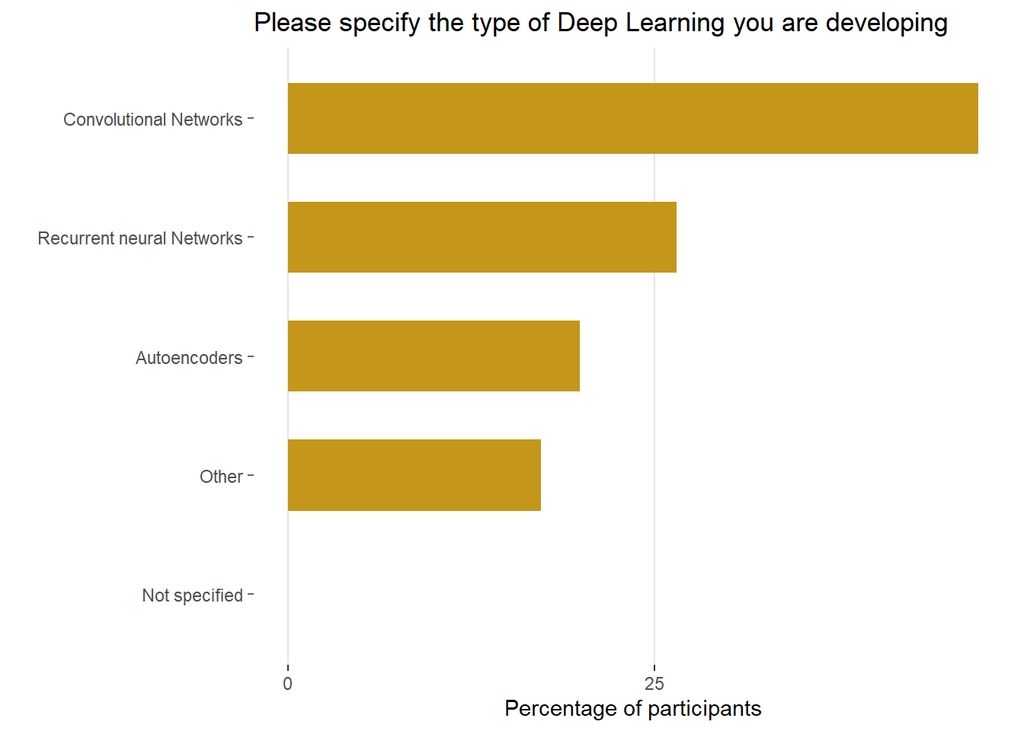

```r
ggplot(dl_analysis1) + geom_col(aes(reorder(row_names, Pct.of.Cases, sum), Pct.of.Cases),
                              fill = bar_color,
                              width = bar_width) +
  labs(x = "", y = "Percentage of participants", title = "Please specify the type of Deep Learning you are developing") +
  scale_y_continuous(breaks = seq(0,200,25)) +
  coord_flip() +
  bar_theme
```

## In which of the following areas of AI are you developing?

```r
which(colnames(analysis) == "ki_bereich___1")
```

```
## [1] 81
```

```r
which(colnames(analysis) == "ki_bereich___7")
```

```
## [1] 87
```

```r
areas_2 <-analysis %>% select(81:87)
view(areas_2)
```

**Multi-response analysis** *Pct.of.cases is the percentage of respondents who selected that particular option. You’ll notice that these don’t add up to 100% because people could choose more than one option.Pct.of.resp. is the percentage of responses (so not like I said in the video respondents, but responses). These do add up to 100%.*

```r
areas_2_analysis <-data.frame(Freq = colSums(areas_2),
           Pct.of.Resp = (colSums(areas_2)/sum(areas_2))*100,
           Pct.of.Cases = (colSums(areas_2)/nrow(areas_2))*100)
```

```r
rownames(areas_2_analysis) <- c("Natural Language Processing","Clinical Decision Support","Image processing", "Computer vision", "Robotics", "Other", "Not specified")
knitr::kable(areas_2_analysis)
```

|  | Freq | Pct.of.Resp | Pct.of.Cases |
| --- | --- | --- | --- |
| Natural Language Processing | 39 | 15.175097 | 25.827815 |
| Clinical Decision Support | 53 | 20.622568 | 35.099338 |
| Image processing | 64 | 24.902724 | 42.384106 |
| Computer vision | 50 | 19.455253 | 33.112583 |
| Robotics | 16 | 6.225681 | 10.596027 |
| Other | 21 | 8.171206 | 13.907285 |
| Not specified | 14 | 5.447471 | 9.271523 |

*create bar graph* *rownames as column*

```r
areas_2_analysis1 <- areas_2_analysis
areas_2_analysis1$row_names <- row.names(areas_2_analysis1)
areas_2_analysis1
```

```
##                             Freq Pct.of.Resp Pct.of.Cases
## Natural Language Processing   39   15.175097    25.827815
## Clinical Decision Support     53   20.622568    35.099338
## Image processing              64   24.902724    42.384106
## Computer vision               50   19.455253    33.112583
## Robotics                      16    6.225681    10.596026
## Other                         21    8.171206    13.907285
## Not specified                 14    5.447471     9.271523
##                                               row_names
## Natural Language Processing Natural Language Processing
## Clinical Decision Support     Clinical Decision Support
## Image processing                       Image processing
## Computer vision                         Computer vision
## Robotics                                       Robotics
## Other                                             Other
## Not specified                             Not specified
```

*graph*

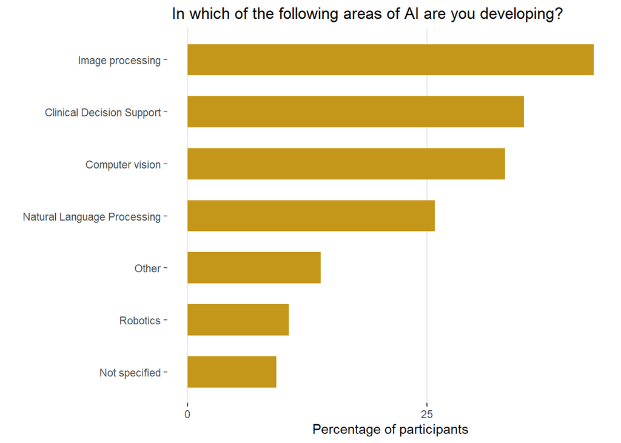

```r
ggplot(areas_2_analysis1) + geom_col(aes(reorder(row_names, Pct.of.Cases, sum), Pct.of.Cases),
                              fill = bar_color,
                              width = bar_width) +
  labs(x = "", y = "Percentage of participants", title = " In which of the following areas of AI are you developing?") +
  scale_y_continuous(breaks = seq(0,200,25)) +
  coord_flip() +
  bar_theme
```

# Main Outcomes

## How familiar are you with biases in AI?

```r
familiar <- analysis %>%
  group_by(bias_ki) %>%
  summarize(N = n()) %>%
  mutate(Percent = N / sum(N) * 100,
         Percent = round(Percent, 1)) %>%
  arrange(desc(N))

familiar$bias_ki <- factor(familiar$bias_ki,levels = c(1,2,3), labels = c("I have never heard of biases in AI","I have heard of biases in AI but I can not think ofconcrete examples","I have heard of biases in AI and I do know specifi cuse cases"))

knitr::kable(familiar)
```

| bias_ki | N | Percent |
| --- | --- | --- |
| I have heard of biases in AI and I do know specifi cuse cases | 113 | 74.8 |
| I have heard of biases in AI but I can not think ofconcrete examples | 30 | 19.9 |
| I have never heard of biases in AI | 8 | 5.3 |

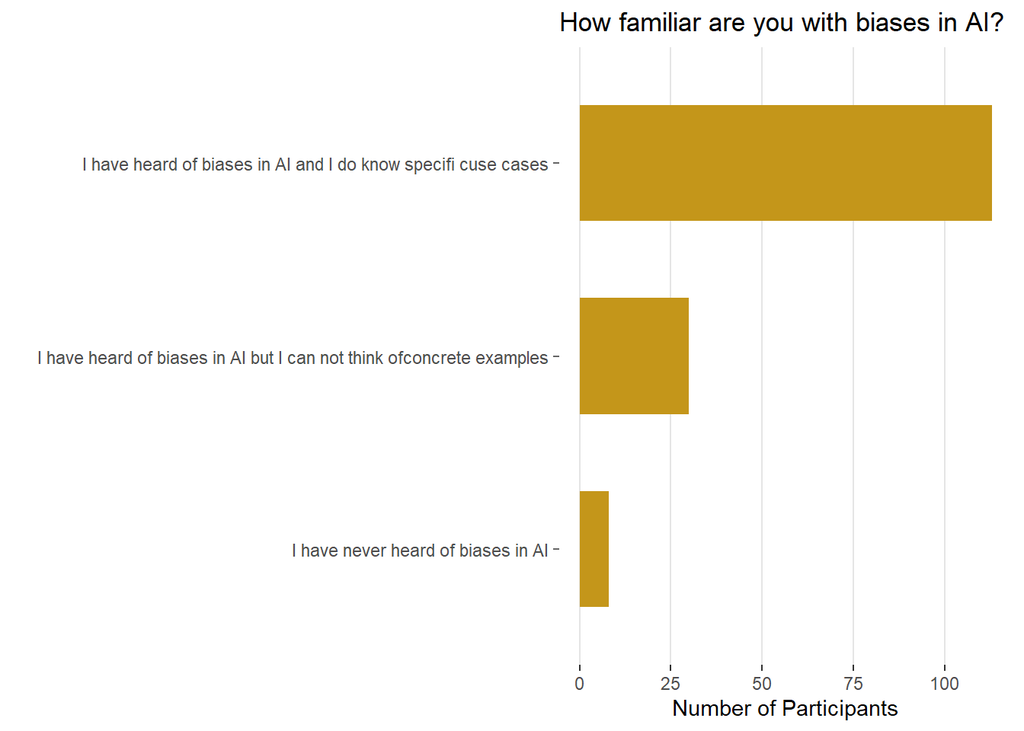

```r
ggplot(familiar) + geom_col(aes(reorder(bias_ki, N, sum), N),
                              fill = bar_color,
                              width = bar_width) +
  labs(x = "", y = "Number of Participants", title = "How familiar are you with biases in AI?") +
  scale_y_continuous(breaks = seq(0,200,25)) +
  coord_flip() +
  bar_theme
```

## Where do you think biases in AI can occur?

```r
which(colnames(analysis) == "bias_feld___1")
```

```
## [1] 90
```

```r
which(colnames(analysis) == "bias_feld___6")
```

```
## [1] 95
```

```r
occur <-analysis %>% select(90:95)
view(occur)
```

**Multi-response analysis** *Pct.of.cases is the percentage of respondents who selected that particular option. You’ll notice that these don’t add up to 100% because people could choose more than one option.Pct.of.resp. is the percentage of responses (so not like I said in the video respondents, but responses). These do add up to 100%.*

```r
occur_2_analysis <-data.frame(Freq = colSums(occur),
           Pct.of.Resp = (colSums(occur)/sum(occur))*100,
           Pct.of.Cases = (colSums(occur)/nrow(occur))*100)
```

```r
rownames(occur_2_analysis) <- c("Methodology \nof algorithms","Societal factors","Bias due to data\nvalidation or \ndata security", "Not specified", "Other", "None of the above")
knitr::kable(occur_2_analysis)
```

[output not shown]

```r
occur_2_analysis1 <- occur_2_analysis
occur_2_analysis1$row_names <- row.names(occur_2_analysis1)
occur_2_analysis1
```

```
##                                                 Freq Pct.of.Resp Pct.of.Cases
## Methodology \nof algorithms                       99  27.1232877    65.562914
## Societal factors                                 126  34.5205479    83.443709
## Bias due to data\nvalidation or \ndata security  119  32.6027397    78.807947
## Not specified                                      3   0.8219178     1.986755
## Other                                             18   4.9315068    11.920530
## None of the above                                  0   0.0000000     0.000000
##                                                                                       row_names
## Methodology \nof algorithms                                         Methodology \nof algorithms
## Societal factors                                                               Societal factors
## Bias due to data\nvalidation or \ndata security Bias due to data\nvalidation or \ndata security
## Not specified                                                                     Not specified
## Other                                                                                     Other
## None of the above                                                             None of the above
```

*graph*

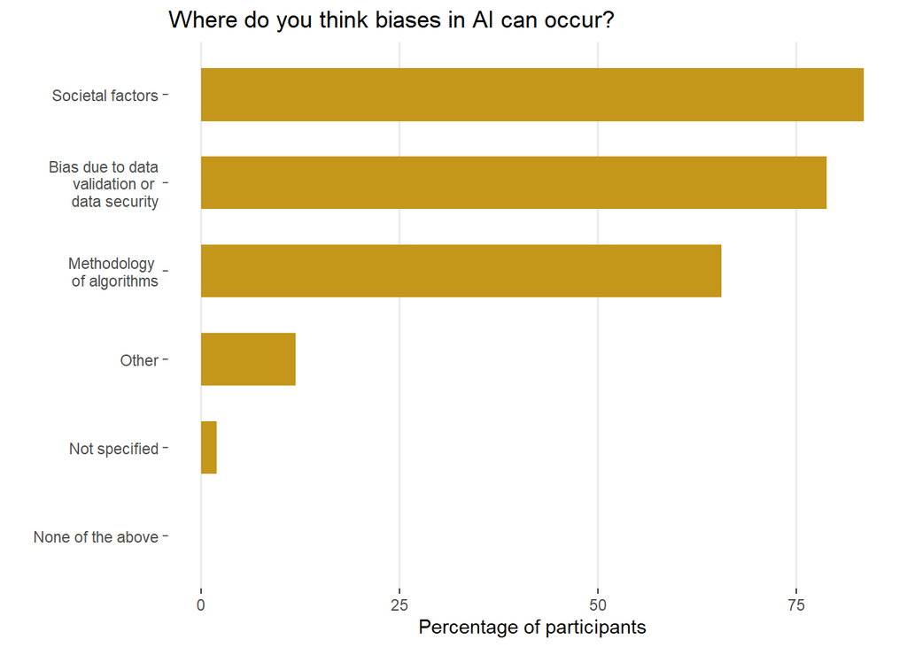

```r
ggplot(occur_2_analysis1) + geom_col(aes(reorder(row_names, Pct.of.Cases, sum), Pct.of.Cases),
                              fill = bar_color,
                              width = bar_width) +
  labs(x = "", y = "Percentage of participants", title = "Where do you think biases in AI can occur?") +
  scale_y_continuous(breaks = seq(0,200,25)) +
  coord_flip() +
  bar_theme
```

## What data do you use to train AI algorithms?

```r
which(colnames(analysis) == "ki_trainingsdaten___1")
```

```
## [1] 97
```

```r
which(colnames(analysis) == "ki_trainingsdaten___4")
```

```
## [1] 100
```

```r
train <-analysis %>% select(97:100)
view(train)
```

**Multi-response analysis** *Pct.of.cases is the percentage of respondents who selected that particular option. You’ll notice that these don’t add up to 100% because people could choose more than one option.Pct.of.resp. is the percentage of responses (so not like I said in the video respondents, but responses). These do add up to 100%.*

```r
train_2_analysis <-data.frame(Freq = colSums(train),
           Pct.of.Resp = (colSums(train)/sum(train))*100,
           Pct.of.Cases = (colSums(train)/nrow(train))*100)
```

```r
rownames(train_2_analysis) <- c("Image data","Audio data","Text data", "Not specified")
knitr::kable(train_2_analysis)
```

|  | Freq | Pct.of.Resp | Pct.of.Cases |
| --- | --- | --- | --- |
| Image data | 83 | 41.089109 | 54.96689 |
| Audio data | 18 | 8.910891 | 11.92053 |
| Text data | 77 | 38.118812 | 50.99338 |
| Not specified | 24 | 11.881188 | 15.89404 |

*create bar graph* *rownames as column*

```r
train_2_analysis1 <- train_2_analysis
train_2_analysis1$row_names <- row.names(train_2_analysis1)
train_2_analysis1
```

```
##               Freq Pct.of.Resp Pct.of.Cases     row_names
## Image data      83   41.089109     54.96689    Image data
## Audio data      18    8.910891     11.92053    Audio data
## Text data       77   38.118812     50.99338     Text data
## Not specified   24   11.881188     15.89404 Not specified
```

*graph*

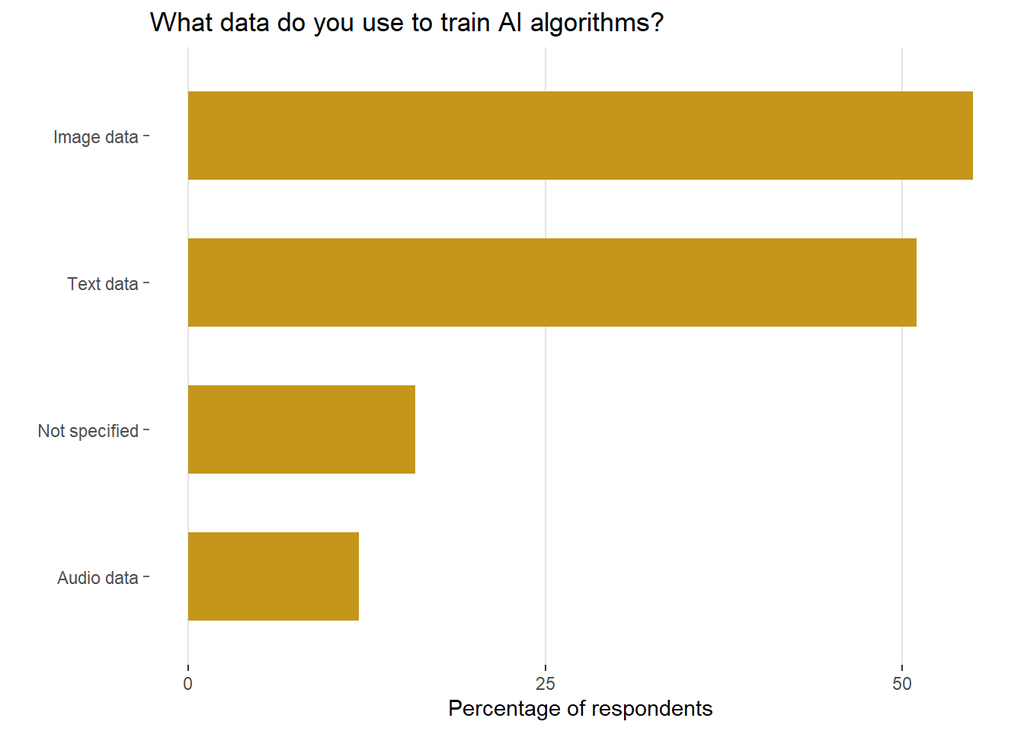

```r
ggplot(train_2_analysis1) + geom_col(aes(reorder(row_names, Pct.of.Cases, sum), Pct.of.Cases),
                              fill = bar_color,
                              width = bar_width) +
  labs(x = "", y = "Percentage of respondents", title = "What data do you use to train AI algorithms?") +
  scale_y_continuous(breaks = seq(0,200,25)) +
  coord_flip() +
  bar_theme
```

## What is the origin of your data?

```r
which(colnames(analysis) == "ki_daten_quelle___1")
```

```
## [1] 101
```

```r
which(colnames(analysis) == "ki_daten_quelle___6")
```

```
## [1] 106
```

```r
origin <-analysis %>% select( 101:106)
view(origin)
```

**Multi-response analysis** *Pct.of.cases is the percentage of respondents who selected that particular option. You’ll notice that these don’t add up to 100% because people could choose more than one option.Pct.of.resp. is the percentage of responses (so not like I said in the video respondents, but responses). These do add up to 100%.*

```r
origin_2_analysis <-data.frame(Freq = colSums(origin),
           Pct.of.Resp = (colSums(origin)/sum(origin))*100,
           Pct.of.Cases = (colSums(origin)/nrow(origin))*100)
```

```r
rownames(origin_2_analysis) <- c("Wearables","Registries","Database from\none center", "Multi-center\ndatabase", "Other", "Not specified")

knitr::kable(origin_2_analysis)
```

|  | Freq | Pct.of.Resp | Pct.of.Cases |
| --- | --- | --- | --- |
| Wearables | 18 | 8.219178 | 11.92053 |
| Registries | 25 | 11.415525 | 16.55629 |
| Database from |  |  |  |
| one center | 76 | 34.703196 | 50.33113 |
| Multi-center |  |  |  |
| database | 50 | 22.831050 | 33.11258 |
| Other | 32 | 14.611872 | 21.19205 |
| Not specified | 18 | 8.219178 | 11.92053 |

*create bar graph* *rownames as column*

```r
origin_2_analysis1 <- origin_2_analysis
origin_2_analysis1$row_names <- row.names(origin_2_analysis1)
origin_2_analysis1
```

```
##                           Freq Pct.of.Resp Pct.of.Cases
## Wearables                   18    8.219178     11.92053
## Registries                  25   11.415525     16.55629
## Database from\none center   76   34.703196     50.33113
## Multi-center\ndatabase      50   22.831050     33.11258
## Other                       32   14.611872     21.19205
## Not specified               18    8.219178     11.92053
##                                           row_names
## Wearables                                 Wearables
## Registries                               Registries
## Database from\none center Database from\none center
## Multi-center\ndatabase       Multi-center\ndatabase
## Other                                         Other
## Not specified                         Not specified
```

*graph*

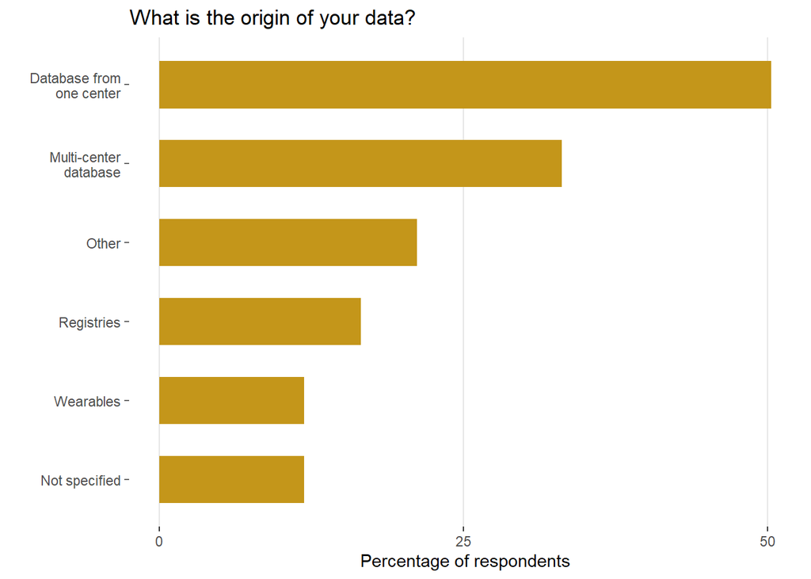

```r
ggplot(origin_2_analysis1) + geom_col(aes(reorder(row_names, Pct.of.Cases, sum), Pct.of.Cases),
                              fill = bar_color,
                              width = bar_width) +
  labs(x = "", y = "Percentage of respondents", title = "What is the origin of your data?") +
  scale_y_continuous(breaks = seq(0,200,25)) +
  coord_flip() +
  bar_theme
```

## Do you work with national or international data?

```r
national <- analysis %>%
  group_by(nat_internat_daten) %>%
  summarize(N = n()) %>%
  mutate(Percent = N / sum(N) * 100,
         Percent = round(Percent, 1)) %>%
  arrange(desc(N))

national$nat_internat_daten <- factor(national$nat_internat_daten,levels = c(1,2,3, 4), labels = c("National data","International data","National and international data", "Not specified"))

knitr::kable(national)
```

| nat_internat_daten | N | Percent |
| --- | --- | --- |
| National data | 53 | 35.1 |
| National and international data | 50 | 33.1 |
| Not specified | 29 | 19.2 |
| International data | 19 | 12.6 |

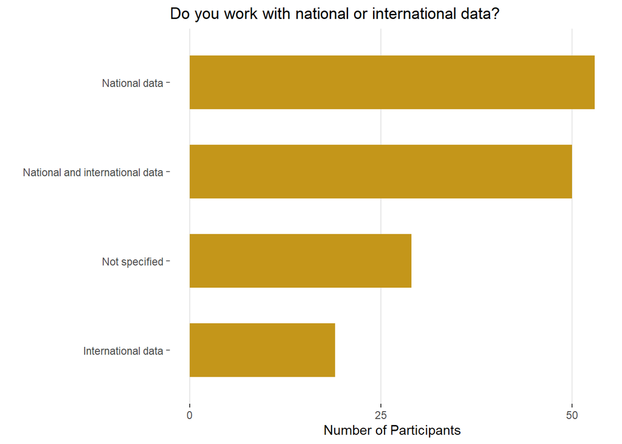

```r
ggplot(national) + geom_col(aes(reorder(nat_internat_daten, N, sum), N),
                              fill = bar_color,
                              width = bar_width) +
  labs(x = "", y = "Number of Participants", title = "Do you work with national or international data?") +
  scale_y_continuous(breaks = seq(0,200,25)) +
  coord_flip() +
  bar_theme
```

## Do you think that using standardized data (internationalsemantic and syntactic standards such as HL7 FHIR, SNOMEDCT) when training AI algorithms can prevent bias? (radio)

```r
standard <- analysis %>%
  group_by(standard_daten) %>%
  summarize(N = n()) %>%
  mutate(Percent = N / sum(N) * 100,
         Percent = round(Percent, 1)) %>%
  arrange(desc(N))

standard$standard_daten <- factor(standard$standard_daten,levels = c(1,2,3), labels = c("Yes","No","Not specified"))

knitr::kable(standard)
```

| standard_daten | N | Percent |
| --- | --- | --- |
| No | 66 | 43.7 |
| Not specified | 48 | 31.8 |
| Yes | 37 | 24.5 |

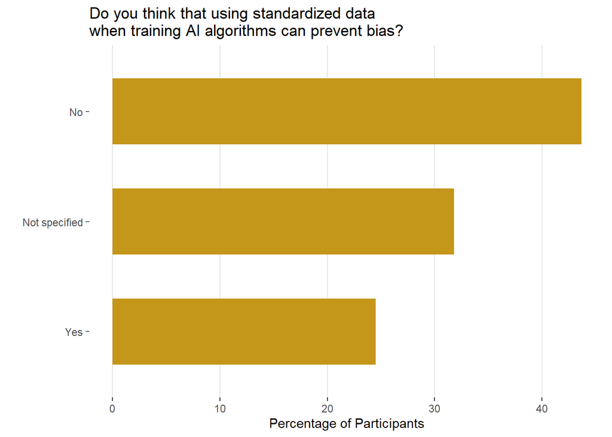

```r
ggplot(standard) + geom_col(aes(reorder(standard_daten, Percent, sum), Percent),
                              fill = bar_color,
                              width = bar_width) +
  labs(x = "", y = "Percentage of Participants", title = "Do you think that using standardized data\nwhen training AI algorithms can prevent bias?") +
  scale_y_continuous(breaks = seq(0,100,10)) +
  coord_flip() +
  bar_theme
```

## Do you know any of the following preventive measures to avoid bias in AI applications?

```r
which(colnames(analysis) == "massnahmen_bias___1")
```

```
## [1] 110
```

```r
which(colnames(analysis) == "massnahmen_bias___6")
```

```
## [1] 115
```

```r
measures <-analysis %>% select( 110:115)
view(measures)
```

**Multi-response analysis** *Pct.of.cases is the percentage of respondents who selected that particular option. You’ll notice that these don’t add up to 100% because people could choose more than one option.Pct.of.resp. is the percentage of responses (so not like I said in the video respondents, but responses). These do add up to 100%.*

```r
measures_analysis <-data.frame(Freq = colSums(measures),
           Pct.of.Resp = (colSums(measures)/sum(measures))*100,
           Pct.of.Cases = (colSums(measures)/nrow(measures))*100)
```

```r
rownames(measures_analysis) <- c("Employ Explainable\nArtificial Intelligence (XAI)","Collecting sociodemographic\ndata points", "Statistical analysis", "Software evaluating\nfairness in AI", "I do not know\nany of them", "Other")

knitr::kable(measures_analysis)
```

|  | Freq | Pct.of.Resp | Pct.of.Cases |
| --- | --- | --- | --- |
| Employ Explainable |  |  |  |
| Artificial Intelligence (XAI) | 85 | 27.8688525 | 56.291391 |
| Collecting sociodemographic |  |  |  |
| data points | 53 | 17.3770492 | 35.099338 |
| Statistical analysis | 95 | 31.1475410 | 62.913907 |
| Software evaluating |  |  |  |
| fairness in AI | 44 | 14.4262295 | 29.139073 |
| I do not know |  |  |  |
| any of them | 25 | 8.1967213 | 16.556291 |
| Other | 3 | 0.9836066 | 1.986755 |

*create bar graph* *rownames as column*

```r
measures_analysis1 <- measures_analysis
measures_analysis1$row_names <- row.names(measures_analysis1)
measures_analysis1
```

[output not shown]

*graph*

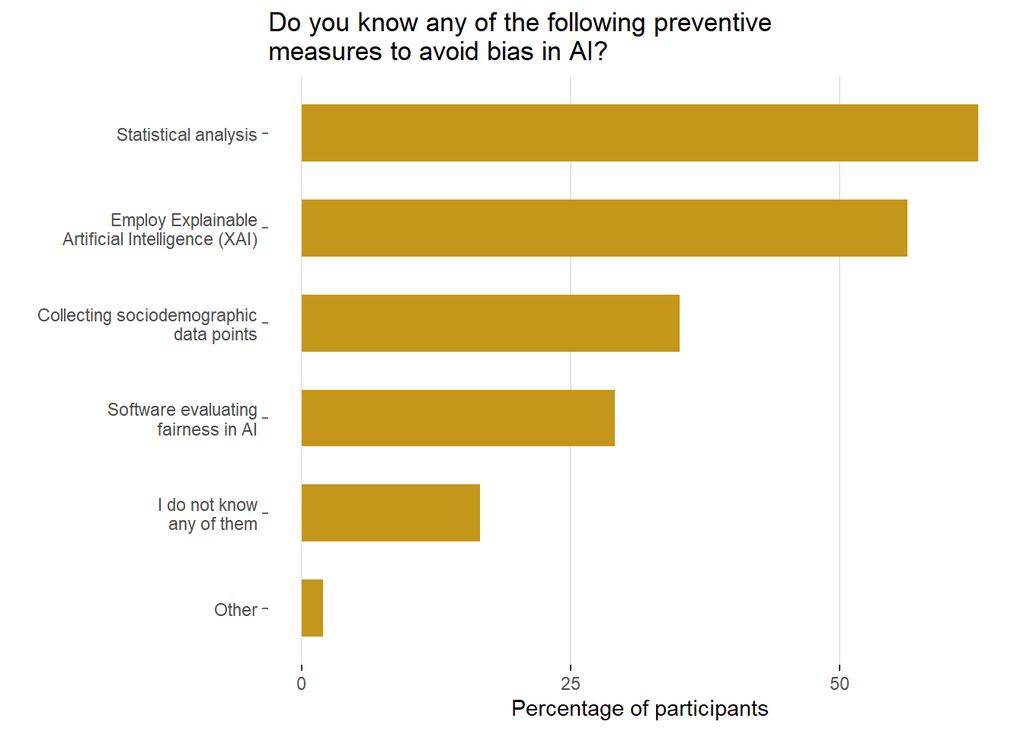

```r
ggplot(measures_analysis1) + geom_col(aes(reorder(row_names, Pct.of.Cases, sum), Pct.of.Cases),
                              fill = bar_color,
                              width = bar_width) +
  labs(x = "", y = "Percentage of participants", title = "Do you know any of the following preventive\nmeasures to avoid bias in AI?") +
  scale_y_continuous(breaks = seq(0,200,25)) +
  coord_flip() +
  bar_theme
```

## What sociodemographic data would you collect to prevent biases in AI?

```r
which(colnames(analysis) == "soziodem_daten___1")
```

```
## [1] 117
```

```r
which(colnames(analysis) == "soziodem_daten___7")
```

```
## [1] 123
```

```r
soziodem <-analysis %>% select( 117:123)
view(soziodem)
```

**Multi-response analysis** *Pct.of.cases is the percentage of respondents who selected that particular option. You’ll notice that these don’t add up to 100% because people could choose more than one option.Pct.of.resp. is the percentage of responses (so not like I said in the video respondents, but responses). These do add up to 100%.*

```r
soziodem_analysis <-data.frame(Freq = colSums(soziodem),
           Pct.of.Resp = (colSums(soziodem)/sum(soziodem))*100,
           Pct.of.Cases = (colSums(soziodem)/nrow(soziodem))*100)
```

```r
rownames(soziodem_analysis) <- c("Biological gender","Social gender","Age", "Origin", "Other", "None", "Not specified")

knitr::kable(soziodem_analysis)
```

|  | Freq | Pct.of.Resp | Pct.of.Cases |
| --- | --- | --- | --- |
| Biological gender | 95 | 21.990741 | 62.913907 |
| Social gender | 81 | 18.750000 | 53.642384 |
| Age | 100 | 23.148148 | 66.225166 |
| Origin | 95 | 21.990741 | 62.913907 |
| Other | 23 | 5.324074 | 15.231788 |
| None | 9 | 2.083333 | 5.960265 |
| Not specified | 29 | 6.712963 | 19.205298 |

*create bar graph* *rownames as column*

```r
soziodem_analysis1 <- soziodem_analysis
soziodem_analysis1$row_names <- row.names(soziodem_analysis1)
soziodem_analysis1
```

```
##                   Freq Pct.of.Resp Pct.of.Cases         row_names
## Biological gender   95   21.990741    62.913907 Biological gender
## Social gender       81   18.750000    53.642384     Social gender
## Age                100   23.148148    66.225166               Age
## Origin              95   21.990741    62.913907            Origin
## Other               23    5.324074    15.231788             Other
## None                 9    2.083333     5.960265              None
## Not specified       29    6.712963    19.205298     Not specified
```

*graph*

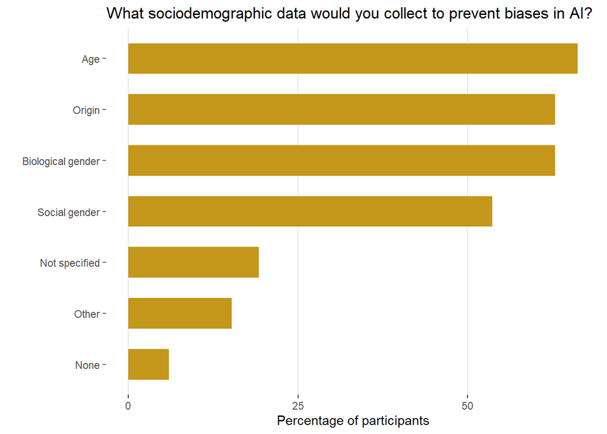

```r
ggplot(soziodem_analysis1) + geom_col(aes(reorder(row_names, Pct.of.Cases, sum), Pct.of.Cases),
                              fill = bar_color,
                              width = bar_width) +
  labs(x = "", y = "Percentage of participants", title = "What sociodemographic data would you collect to prevent biases in AI?") +
  scale_y_continuous(breaks = seq(0,200,25)) +
  coord_flip() +
  bar_theme
```

## What would you use the collected sociodemographic data for?

```r
which(colnames(analysis) == "soziodem_verwendung___1")
```

```
## [1] 125
```

```r
which(colnames(analysis) == "soziodem_verwendung___4")
```

```
## [1] 128
```

```r
collect <-analysis %>% select(125:128)
view(collect)
nrow(collect)
```

```
## [1] 151
```

**Multi-response analysis** *Pct.of.cases is the percentage of respondents who selected that particular option. You’ll notice that these don’t add up to 100% because people could choose more than one option.Pct.of.resp. is the percentage of responses (so not like I said in the video respondents, but responses). These do add up to 100%.*

```r
collect_analysis <-data.frame(Freq = colSums(collect),
           Pct.of.Resp = (colSums(collect)/sum(collect))*100,
           Pct.of.Cases = (colSums(collect)/nrow(collect))*100)
```

```r
rownames(collect_analysis) <- c("AI modelling","Analysis","Data acquisition", "Not specified")

knitr::kable(collect_analysis)
```

|  | Freq | Pct.of.Resp | Pct.of.Cases |
| --- | --- | --- | --- |
| AI modelling | 57 | 26.146789 | 37.748344 |
| Analysis | 93 | 42.660550 | 61.589404 |
| Data acquisition | 61 | 27.981651 | 40.397351 |
| Not specified | 7 | 3.211009 | 4.635762 |

*create bar graph* *rownames as column*

```r
collect_analysis1 <- collect_analysis
collect_analysis1$row_names <- row.names(collect_analysis1)
collect_analysis1
```

```
##                  Freq Pct.of.Resp Pct.of.Cases        row_names
## AI modelling       57   26.146789    37.748344     AI modelling
## Analysis           93   42.660550    61.589404         Analysis
## Data acquisition   61   27.981651    40.397351 Data acquisition
## Not specified       7    3.211009     4.635762    Not specified
```

*graph*

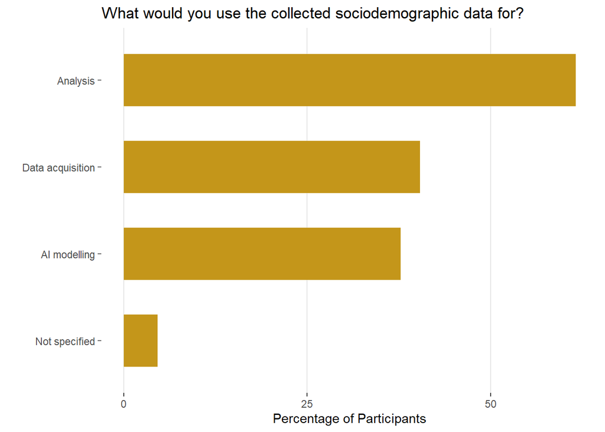

```r
ggplot(collect_analysis1) + geom_col(aes(reorder(row_names, Pct.of.Cases, sum), Pct.of.Cases),
                              fill = bar_color,
                              width = bar_width) +
  labs(x = "", y = "Percentage of Participants", title = "What would you use the collected sociodemographic data for?") +
  scale_y_continuous(breaks = seq(0,200,25)) +
  coord_flip() +
  bar_theme
```

## How would you rate the level of fairness of AI in your AI development? (radio)

```r
levelfair <- analysis %>%
  group_by(fairness_ki) %>%
  summarize(N = n()) %>%
  mutate(Percent = N / sum(N) * 100,
         Percent = round(Percent, 1)) %>%
  arrange(desc(N))

levelfair$fairness_ki <- factor(levelfair$fairness_ki,levels = c(1,2,3,4,5,6), labels = c("Not fair at all","Barely fair","Moderately fair", "Fair", "Very fair", "Not specifi ed"))

knitr::kable(levelfair)
```

| fairness_ki | N | Percent |
| --- | --- | --- |
| Moderately fair | 51 | 33.8 |
| Fair | 47 | 31.1 |
| Very fair | 19 | 12.6 |
| Barely fair | 18 | 11.9 |
| Not specifi ed | 14 | 9.3 |
| Not fair at all | 2 | 1.3 |

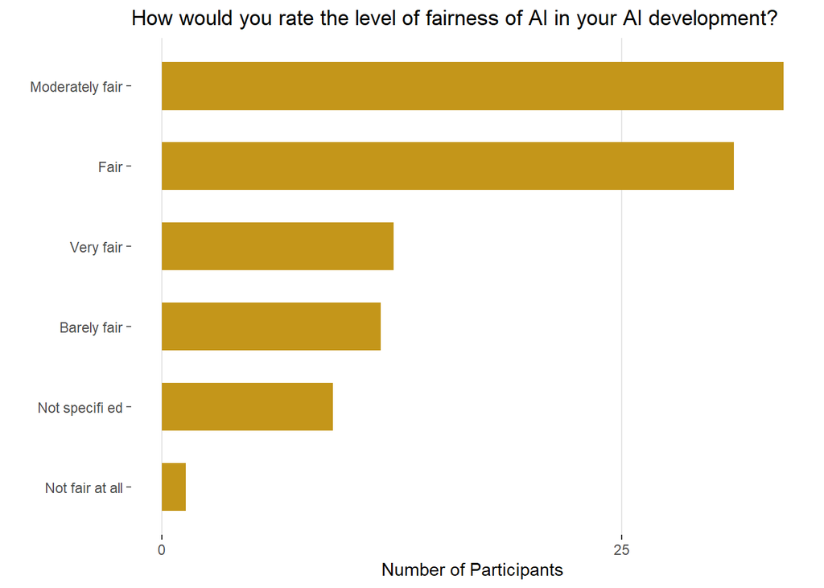

```r
ggplot(levelfair) + geom_col(aes(reorder(fairness_ki, Percent, sum), Percent),
                              fill = bar_color,
                              width = bar_width) +
  labs(x = "", y = "Number of Participants", title = "How would you rate the level of fairness of AI in your AI development?") +
  scale_y_continuous(breaks = seq(0,200,25)) +
  coord_flip() +
  bar_theme
```

## What do you think is preventing fair AI in your use case?

```r
which(colnames(analysis) == "fairness_ki_block___1")
```

```
## [1] 130
```

```r
which(colnames(analysis) == "fairness_ki_block___7")
```

```
## [1] 136
```

```r
which(colnames(analysis) == "fairness_ki")
```

```
## [1] 129
```

```r
prevent <-analysis %>% select(130:136, 129)
view(prevent)
nrow(prevent)
```

```
## [1] 151
```

*Show the fi eld ONLY if:* *[fairness_ki_1] = ‘1’ or [fairness_ki_1] = ‘2’ or [fairness_ki_1] =‘3’ or [fairness_ki_1] = ‘4’ or [fairness_ki_1] = ‘6’*

```r
prevent <- prevent[(prevent$fairness_ki==1    | prevent$fairness_ki==2    | prevent$fairness_ki==3 | prevent$fairness_ki==4| prevent$fairness_ki==6),]
nrow(prevent)
```

```
## [1] 132
```

*drop column*

```r
prevent <- subset(prevent, select = -c(fairness_ki))
```

**Multi-response analysis** *Pct.of.cases is the percentage of respondents who selected that particular option. You’ll notice that these don’t add up to 100% because people could choose more than one option.Pct.of.resp. is the percentage of responses (so not like I said in the video respondents, but responses). These do add up to 100%.*

```r
prevent_analysis <-data.frame(Freq = colSums(prevent),
           Pct.of.Resp = (colSums(prevent)/sum(prevent))*100,
           Pct.of.Cases = (colSums(prevent)/nrow(prevent))*100)
```

*Create table*

```r
rownames(prevent_analysis) <- c("Lack of resources","Lack of support from \nsuperiors/institution","Lack of knowledge", "Lack of fair data", "Lack of guidelines/\nrecommendations", "Other", "Not specified")

knitr::kable(prevent_analysis)
```

[output not shown]

*create bar graph* *rownames as column*

```r
prevent_analysis1 <- prevent_analysis
prevent_analysis1$row_names <- row.names(prevent_analysis1)
prevent_analysis1
```

```
##                                              Freq Pct.of.Resp Pct.of.Cases
## Lack of resources                              48   16.326531    36.363636
## Lack of support from \nsuperiors/institution   12    4.081633     9.090909
## Lack of knowledge                              60   20.408163    45.454545
## Lack of fair data                              90   30.612245    68.181818
## Lack of guidelines/\nrecommendations           65   22.108844    49.242424
## Other                                           7    2.380952     5.303030
## Not specified                                  12    4.081633     9.090909
##                                                                                 row_names
## Lack of resources                                                       Lack of resources
## Lack of support from \nsuperiors/institution Lack of support from \nsuperiors/institution
## Lack of knowledge                                                       Lack of knowledge
## Lack of fair data                                                       Lack of fair data
## Lack of guidelines/\nrecommendations                 Lack of guidelines/\nrecommendations
## Other                                                                               Other
## Not specified                                                               Not specified
```

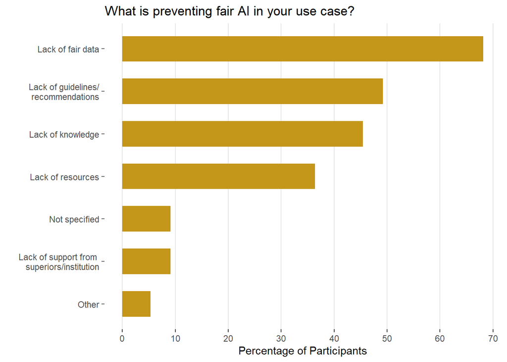

```r
ggplot(prevent_analysis1) + geom_col(aes(reorder(row_names, Pct.of.Cases, sum), Pct.of.Cases),
                              fill = bar_color,
                              width = bar_width) +
  labs(x = "", y = "Percentage of Participants", title = "What is preventing fair AI in your use case?") +
  scale_y_continuous(breaks = seq(0,100,10)) +
  coord_flip() +
  bar_theme
```

# By Gender and Age

```r
library(arsenal)
```

## create dataset for subanalysis

```r
genderfair <-analysis %>% select(fairness_ki, geschlecht, alter, sektor, agegroup2, agegroup4)
view(genderfair)
nrow(genderfair)
```

```
## [1] 151
```

```r
is.factor(genderfair$geschlecht)
```

```
## [1] TRUE
```

```r
is.factor(genderfair$fairness_ki)
```

```
## [1] FALSE
```

```r
is.factor(genderfair$sektor)
```

```
## [1] TRUE
```

```r
is.factor(genderfair$agegroup2)
```

```
## [1] TRUE
```

```r
is.factor(genderfair$agegroup4)
```

```
## [1] TRUE
```

```r
is.numeric(genderfair$alter)
```

```
## [1] TRUE
```

```r
genderfair$fairness_ki = as.factor(genderfair$fairness_ki)
genderfair$fairness_ki <- factor(genderfair$fairness_ki,levels = c(1,2,3,4,5,6), labels = c("Not fair at all","Barely fair","Moderately fair", "Fair", "Very fair", "Not specified"))
genderfair$geschlecht <- factor(genderfair$geschlecht,levels = c(1,2), labels = c("female", "male"))
```

```r
library(data.table)
```

### convert to data table

```r
is.data.table(genderfair) == TRUE
```

```
## [1] TRUE
```

# Write File for Analysis

```r
write_xlsx(genderfair, 'genderfair.xlsx')
```

## Age Group 4

```r
table(genderfair$fairness_ki, genderfair$agegroup4)
```

```
##
##                   <30 30-40 40-50 >50
##   Not fair at all   0     0     1   1
##   Barely fair       7     5     5   1
##   Moderately fair  29    12     9   1
##   Fair             21    19     4   3
##   Very fair         9     6     3   1
##   Not specified     3     7     2   2
```

```r
table2 = table(genderfair$fairness_ki, genderfair$agegroup4)
chisq.test(table2)
```

```
##
##  Pearson's Chi-squared test
##
## data:  table2
## X-squared = 22.926, df = 15, p-value = 0.08572
```

```r
chisq.test(table2)$expected
```

```
##
##                          <30      30-40     40-50       >50
##   Not fair at all  0.9139073  0.6490066 0.3178808 0.1192053
##   Barely fair      8.2251656  5.8410596 2.8609272 1.0728477
##   Moderately fair 23.3046358 16.5496689 8.1059603 3.0397351
##   Fair            21.4768212 15.2516556 7.4701987 2.8013245
##   Very fair        8.6821192  6.1655629 3.0198675 1.1324503
##   Not specified    6.3973510  4.5430464 2.2251656 0.8344371
```

```r
round(prop.table(table2,2),2)
```

```
##
##                    <30 30-40 40-50  >50
##   Not fair at all 0.00  0.00  0.04 0.11
##   Barely fair     0.10  0.10  0.21 0.11
##   Moderately fair 0.42  0.24  0.38 0.11
##   Fair            0.30  0.39  0.17 0.33
##   Very fair       0.13  0.12  0.12 0.11
##   Not specified   0.04  0.14  0.08 0.22
```

Age Group 2

```r
table(genderfair$fairness_ki, genderfair$agegroup2)
```

```
##
##                    0  1
##   Not fair at all  2  0
##   Barely fair     11  7
##   Moderately fair 22 29
##   Fair            26 21
##   Very fair       10  9
##   Not specified   11  3
```

```r
table2 = table(genderfair$fairness_ki, genderfair$agegroup2)
chisq.test(table2)
```

```
##
##  Pearson's Chi-squared test
##
## data:  table2
## X-squared = 7.9453, df = 5, p-value = 0.1593
```

```r
chisq.test(table2)$expected
```

```
##
##                           0          1
##   Not fair at all  1.086093  0.9139073
##   Barely fair      9.774834  8.2251656
##   Moderately fair 27.695364 23.3046358
##   Fair            25.523179 21.4768212
##   Very fair       10.317881  8.6821192
##   Not specified    7.602649  6.3973510
```

```r
round(prop.table(table2,2),2)
```

```
##
##                      0    1
##   Not fair at all 0.02 0.00
##   Barely fair     0.13 0.10
##   Moderately fair 0.27 0.42
##   Fair            0.32 0.30
##   Very fair       0.12 0.13
##   Not specified   0.13 0.04
```

## gender

```r
genderfair <- genderfair %>% drop_na(geschlecht)
nrow(genderfair)
```

```
## [1] 146
```

## Chi Square

```r
table(genderfair$fairness_ki, genderfair$geschlecht)
```

```
##
##                   female male
##   Not fair at all      0    2
##   Barely fair          7    8
##   Moderately fair     13   37
##   Fair                12   35
##   Very fair            6   13
##   Not specified        7    6
```

```r
table1 = table(genderfair$fairness_ki, genderfair$geschlecht)
chisq.test(table1)
```

```
##
##  Pearson's Chi-squared test
##
## data:  table1
## X-squared = 7.0566, df = 5, p-value = 0.2165
```

```r
chisq.test(table1)$expected
```

```
##
##                       female      male
##   Not fair at all  0.6164384  1.383562
##   Barely fair      4.6232877 10.376712
##   Moderately fair 15.4109589 34.589041
##   Fair            14.4863014 32.513699
##   Very fair        5.8561644 13.143836
##   Not specified    4.0068493  8.993151
```

###column%

```r
round(prop.table(table1,2),2)
```

```
##
##                   female male
##   Not fair at all   0.00 0.02
##   Barely fair       0.16 0.08
##   Moderately fair   0.29 0.37
##   Fair              0.27 0.35
##   Very fair         0.13 0.13
##   Not specified     0.16 0.06
```

## Sektor

genderfair$sektor <- factor(genderfair$sektor,levels = c(1,2,3,4,5), labels = c(“Science”,“Clinical Work”,“Industry”, “Other”, “Not specified”))

```r
genderfair_2 <- subset(genderfair, genderfair$sektor != 4 & genderfair$sektor !=  5)
```

```r
genderfair_2$sektor <- factor(genderfair_2$sektor,levels = c(1,2,3), labels = c("Science","Clinical Work","Industry"))
```

```r
table(genderfair_2$fairness_ki, genderfair_2$sektor)
```

```
##
##                   Science Clinical Work Industry
##   Not fair at all       0             1        0
##   Barely fair          10             2        1
##   Moderately fair      39             3        5
##   Fair                 32             5        6
##   Very fair            10             1        6
##   Not specified         8             0        4
```

```r
table1 = table(genderfair_2$fairness_ki, genderfair_2$sektor)
chisq.test(table1)
```

```
##
##  Pearson's Chi-squared test
##
## data:  table1
## X-squared = 21.186, df = 10, p-value = 0.01983
```

```r
chisq.test(table1)$expected
```

```
##
##                      Science Clinical Work  Industry
##   Not fair at all  0.7443609    0.09022556 0.1654135
##   Barely fair      9.6766917    1.17293233 2.1503759
##   Moderately fair 34.9849624    4.24060150 7.7744361
##   Fair            32.0075188    3.87969925 7.1127820
##   Very fair       12.6541353    1.53383459 2.8120301
##   Not specified    8.9323308    1.08270677 1.9849624
```

###column%

```r
round(prop.table(table1,2),2)
```

```
##
##                   Science Clinical Work Industry
##   Not fair at all    0.00          0.08     0.00
##   Barely fair        0.10          0.17     0.05
##   Moderately fair    0.39          0.25     0.23
##   Fair               0.32          0.42     0.27
##   Very fair          0.10          0.08     0.27
##   Not specified      0.08          0.00     0.18
```